# 03. 텍스트 처리 및 분류 (정규표현식, BoW, DTM, TF-IDF, 분류모델)

## 텍스트 처리(Text Processing)

- 전자 텍스트의 생성 또는 조작을 자동화하는 방법
- 텍스트(Text)는 사람의 키보드를 통해 지정된 영숫자 전체를 의미하는 것이 보통이지만 일반적으로 텍스트는 대상 텍스트의 표준 문자 인코딩 바로 위의 추상화 계층을 의미
- 처리(Processing)라는 용어는 자동화된(기계화된) 처리를 의미하며 이는 수동으로 수행되는 동일 조작과는 대조적
- 텍스트 처리는 내용, 내용 변화, 커서 이동을 호출하는 컴퓨터 명령을 수반하며 다음과 같은 응용이 존재
  - 찾아 바꾸기
  - 서식 지정
  - 내용의 처리(가공)된 보고서 생성
  - 파일 또는 텍스트 파일의 보고서를 필터 처리

#### **`텍스트.upper()`**

```python
s = 'AbCdEfGh'
print(s.lower())
print(s.upper())
```

```
abcdefgh
ABCDEFGH
```

```python
s = 'No pain no gain'
print(s.split())
print(s.split().index('gain'))
```

```
['No', 'pain', 'no', 'gain']
3
```

## 정규표현식(Regular Expression)

- 정규 표현식은 특정 문자들을 편리하게 지정하고 추가, 삭제 가능
- 데이터 전처리에서 정규 표현식을 많이 사용
- 파이썬에서는 정규 표현식을 지원하는 `re` 패키지 제공
- 정규 표현식 문법

| 특수문자 | 설명 |
| --- | --- |
| `.` | 앞의 문자 1개를 표현 |
| `?` | 문자 한개를 표현하나 존재할 수도, 존재하지 않을 수도 있음(0개 또는 1개) |
| `*` | 앞의 문자가 0개 이상 |
| `+` | 앞의 문자가 최소 1개 이상 |
| `^` | 뒤의 문자로 문자열이 시작 |
| `\$` | 앞의 문자로 문자열이 끝남 |
| `\{n\}` | `n`번만큼 반복 |
| `\{n1, n2\}` | `n1` 이상, `n2` 이하만큼 반복, n2를 지정하지 않으면 `n1` 이상만 반복 |
| `\[ abc \]` | 안에 문자들 중 한 개의 문자와 매치, a-z처럼 범위도 지정 가능 |
| `\[ ^a \]` | 해당 문자를 제외하고 매치 |
| `a\|b` | `a` 또는 `b`를 나타냄 |

- 정규 표현식에 자주 사용하는 역슬래시(\)를 이용한 문자 규칙

| 문자 | 설명 |
| --- | --- |
| `\\` | 역슬래시 자체를 의미 |
| `\d` | 모든 숫자를 의미, [0-9]와 동일 |
| `\D` | 숫자를 제외한 모든 문자를 의미, [^0-9]와 동일 |
| `\s` | 공백을 의미, [ \t\n\r\f\v]와 동일 |
| `\S` | 공백을 제외한 모든 문자를 의미, [^ \t\n\r\f\v]와 동일 |
| `\w` | 문자와 숫자를 의미, [a-zA-Z0-9]와 동일 |
| `\W` | 문자와 숫자를 제외한 다른 문자를 의미, [^a-zA-Z0-9]와 동일 |

**`match`**: 컴파일한 정규 표현식을 이용해 문자열이 정규 표현식과 맞는지 검사

```python
import re

check = 'ab.' # 'ab'로 시작하는 모든 문자열에 대한 정규표현식

print(re.match(check, 'abc'))
print(re.match(check, 'ab'))
print(re.match(check, 'c'))
```

```
<re.Match object; span=(0, 3), match='abc'>
None
None
```

```python
check = "([ㄱ-ㅎ]+)|([가-힣]+)" # 모든 한글에 대한 정규표현식

print(re.match(check, 'ㅎ'))
print(re.match(check, 'ㅇ안'))
print(re.match(check, '안ㅇ'))
```

```
<re.Match object; span=(0, 1), match='ㅎ'>
<re.Match object; span=(0, 1), match='ㅇ'>
<re.Match object; span=(0, 1), match='안'>
```

**`search`**: **match와 다르게, search는 문자열의 전체를 검사**

```python
check = 'ab?' # 'a'이거나 'ab'인 문자열에 대한 정규표현식

print(re.search(check, 'a'))
print(re.match(check, 'kkkab'))
print(re.search(check, 'kkkab'))
print(re.match(check, 'ab'))
```

```
<re.Match object; span=(0, 1), match='a'>
None
<re.Match object; span=(3, 5), match='ab'>
<re.Match object; span=(0, 2), match='ab'>
```

```python
check = '[ㄱ-ㅎ|ㅏ-ㅣ]+'


print(re.search(check, 'ㄱㅏ안녕하세요.'))

print(re.search(check, '안ㄱㅏ.'))
print(re.match(check, '안ㄱㅏ.'))
```

```
<re.Match object; span=(0, 2), match='ㄱㅏ'>
<re.Match object; span=(1, 3), match='ㄱㅏ'>
None
```

```python
check = '[가-힣]+'

print(re.search(check, 'ㄱㅏ안녕하세요.'))

print(re.search(check, '안ㄱㅏ.'))
print(re.match(check, '안ㄱㅏ.'))
```

```
<re.Match object; span=(2, 7), match='안녕하세요'>
<re.Match object; span=(0, 1), match='안'>
<re.Match object; span=(0, 1), match='안'>
```

**`split`**: 정규표현식에 해당하는 문자열을 기준으로 문자열을 나눔

```python
r = re.compile(' ')

print(r.split('abc abbc'))

r = re.compile('c')
print(r.split('abc abbc'))

r = re.compile('[1-9]')
print(r.split('stabc 2v3s 4sss 5a'))
```

```
['abc', 'abbc']
['ab', ' abb', '']
['stabc ', 'v', 's ', 'sss ', 'a']
```

**`sub`**: 정규 표현식과 일치하는 부분을 다른 문자열로 교체

```python
print(re.sub('[a-z]', 'abcdefg', '1'))

print(re.sub('[^a-z]', 'abcdefg', '1'))
```

```
1
abcdefg
```

```python
print(re.sub('[가-힣]', '가나다라마바사', '1'))

print(re.sub('[^가-힣]', '가나다라마바사', '1'))
```

```
1
가나다라마바사
```

**`findall`**: 컴파일한 정규 표현식을 이용해 정규 표현식과 맞는 모든 문자(열)을 리스트로 반환

```python
print(re.findall('[\d]', '1ab 2cd 3ef 4g'))

print(re.findall('[\W]', '1ab&2cd!? 3''ef@4g'))
```

```
['1', '2', '3', '4']
['&', '!', '?', ' ', '@']
```

**`finditer`**

- 컴파일한 정규 표현식을 이용해 정규 표현식과 맞는 모든 문자(열)을 `iterator` 객체로 반환
- `iterator` 객체를 이용하면 생성된 객체를 하나씩 자동으로 가져올 수 있어 처리가 간편함

```python
iter1 = re.finditer('[\d]', '1ab 2cd 3ef 4g')

for i in iter1:
  print(i)
```

```
<re.Match object; span=(0, 1), match='1'>
<re.Match object; span=(4, 5), match='2'>
<re.Match object; span=(8, 9), match='3'>
<re.Match object; span=(12, 13), match='4'>
```

```python
iter2 = re.finditer('[\W]', '1ab&2cd!? 3''ef@4g')

for i in iter2:
  print(i)
```

```
<re.Match object; span=(3, 4), match='&'>
<re.Match object; span=(7, 8), match='!'>
<re.Match object; span=(8, 9), match='?'>
<re.Match object; span=(9, 10), match=' '>
<re.Match object; span=(13, 14), match='@'>
```

## 단어 표현의 카테고리화

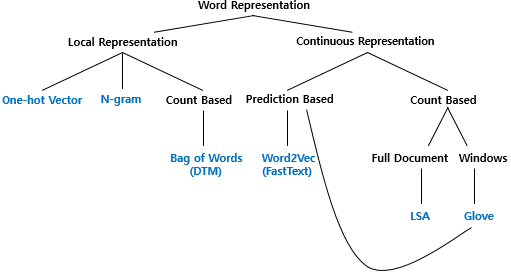

- Bag of Words(BoW)는 국소표현 (Local Representation)에 속하며, 단어의 빈도수를 카운트(Count)하여 단어를 수치화하는 단어 표현 방법
- DTM (또는 TDM)은 BoW의 확장

## Bag of Words(BoW)

- 단어들의 순서와 상관없이 출현 빈도(frequency)에 따라서 표현하는 방법

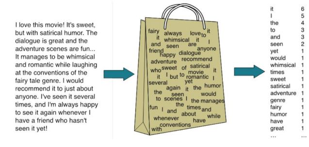

```python
import nltk
from nltk.corpus import stopwords
from nltk.stem import WordNetLemmatizer

nltk.download('punkt')
nltk.download('stopwords')
nltk.download('wordnet')
```

```
True
```

#### **`sklearn.feature_extraction.text.CountVectorizer()`** : BoW 생성 객체

#### **`BoW객체.fit_transform([문자열])`** : BoW 생성

```python
from sklearn.feature_extraction.text import CountVectorizer

corpus = ['Think like a man of action and act like man of though.']

vector = CountVectorizer()
bow = vector.fit_transform(corpus)

print(bow.toarray())
print(vector.vocabulary_)
```

```
[[1 1 1 2 2 2 1 1]]
{'think': 6, 'like': 3, 'man': 4, 'of': 5, 'action': 1, 'and': 2, 'act': 0, 'though': 7}
```

- 불용어 제거 (`stop_words`)

```python
vector = CountVectorizer(stop_words = 'english')
bow = vector.fit_transform(corpus)

print(bow.toarray())
print(vector.vocabulary_)
```

```
[[1 1 2 2 1]]
{'think': 4, 'like': 2, 'man': 3, 'action': 1, 'act': 0}
```

- 한글 BoW

```python
corpus = ['평생 살 것처럼 꿈을 꾸어라. 그리고 내일 죽을 것처럼 오늘을 살아라.']

vector = CountVectorizer()
bow = vector.fit_transform(corpus)

print(bow.toarray())
print(vector.vocabulary_)
```

```
[[2 1 1 1 1 1 1 1 1]]
{'평생': 8, '것처럼': 0, '꿈을': 3, '꾸어라': 2, '그리고': 1, '내일': 4, '죽을': 7, '오늘을': 6, '살아라': 5}
```

## 문서 단어 행렬(DTM)

- 문서 단어 행렬(Document-Term Matrix)은 문서에 등장하는 여러 단어들의 빈도를 행렬로 표현
- **각 문서에 대한 BoW를 하나의 행렬로 표현한 것**

```python
corpus = ['Think like a man of action and act like man of though.',
          'Try not to become a man of success but rather try to become a man of value',
          'Give me liberty, of give me death']

vector = CountVectorizer(stop_words = 'english')
bow = vector.fit_transform(corpus)

print(bow.toarray())
print(vector.vocabulary_)
```

```
[[1 1 0 0 2 2 0 1 0 0]
 [0 0 0 0 0 2 1 0 2 1]
 [0 0 1 1 0 0 0 0 0 0]]
{'think': 7, 'like': 4, 'man': 5, 'action': 1, 'act': 0, 'try': 8, 'success': 6, 'value': 9, 'liberty': 3, 'death': 2}
```

```python
import pandas as pd

columns = []

for k, v in sorted(vector.vocabulary_.items()):
  columns.append(k)

df = pd.DataFrame(bow.toarray(), columns = columns)
df
```

|  | act | action | death | liberty | like | man | success | think | try | value |
| --- | --- | --- | --- | --- | --- | --- | --- | --- | --- | --- |
| 0 | 1 | 1 | 0 | 0 | 2 | 2 | 0 | 1 | 0 | 0 |
| 1 | 0 | 0 | 0 | 0 | 0 | 2 | 1 | 0 | 2 | 1 |
| 2 | 0 | 0 | 1 | 1 | 0 | 0 | 0 | 0 | 0 | 0 |

## 어휘 빈도-문서 역빈도(TF-IDF)

- 어휘 빈도-문서 역빈도(TF-IDF; Term Frequency-Inverse Docunment Frequency)는 단순히 빈도수가 높은 단어가 핵심어가 아닌, 특정 문서에서만 집중적으로 등장할 때 해당 단어가 문서의 주제를 잘 담고 있는 핵심어라고 가정
- **특정 문서에서 특정단어가 많이 등장하고 그 단어가 다른 문서에서 적게 등장할 때, 그 단어를 특정 문서의 핵심어로 간주**
- 어휘 빈도-문서 역빈도는 어휘 빈도와 역문서 빈도를 곱해 계산 가능
- **어휘 빈도**는 특정 문서에서 특정 단어가 많이 등장하는 것을 의미

$$ tf_{x,y} $$

- **역문서 빈도**는 다른 문서에서 등장하지 않는 단어 빈도를 의미

$$ log(N/df_x) $$

- **어휘 빈도-문서 역빈도**는 다음과 같이 표현

$$ W_{x,y} = tf_{x,y} * log(N/df_x) $$

- tf-idf를 편리하게 계산하기 위해 `scikit-learn`의 `Tfidfvectorizer`를 이용
- 앞서 계산한 단어 빈도 수를 입력하여 tf-idf로 변환

#### **`sklearn.feature_extraction.text.TfidfVectorizer()`** : Tf-Idf 생성 객체

#### **`Tf-Idf객체.fit_transform([문자열], sublinear_tf)`** : Tf-Idf 벡터 생성

- `sublinear_tf` : [True = tf값에 $1+log(tf)$를 적용하여 tf값이 무한정 커지는 것을 막음]
- `ngram_range` : (min_n, max_n) 튜플, n-그램 범위
- `max_df` : 단어장에 포함되기 위한 비율 임계점 [정수 또는 [0.0, 1.0] 사이의 실수. (default = 1)] (너무 자주 나타나는 단어를 지우기 위해 사용. 코퍼스 특이적 불용어(corpus-specific stopwords)
  - max_df = 0.50의 의미는 "문서에서 50% 이상 나온 단어를 무시해"라는 의미다.
  - max_df = 25가 의미하는 거은 "25번 이상 나온 단어를 무시해"라는 의미다.
- `min_df` : 단어장에 포함되기 위한 최소 빈도 (default = 1)], (너무 희소하게 나오는 단어를 제거)
  - min_df = 0.01이 의미하는 것은 1%이하로 나온 문서를 무시하라는 의미이다.
  - min_df = 5가 의미하는 것은 5개 이하로 나온 단어에 대해서 무시하라는 의미이다.

https://chan-lab.tistory.com/27

```python
from sklearn.feature_extraction.text import TfidfVectorizer

tfidf = TfidfVectorizer(stop_words = 'english').fit(corpus)

print(tfidf.transform(corpus).toarray())
print(tfidf.vocabulary_)
```

```
[[0.32767345 0.32767345 0.         0.         0.65534691 0.49840822
  0.         0.32767345 0.         0.        ]
 [0.         0.         0.         0.         0.         0.52753275
  0.34682109 0.         0.69364217 0.34682109]
 [0.         0.         0.70710678 0.70710678 0.         0.
  0.         0.         0.         0.        ]]
{'think': 7, 'like': 4, 'man': 5, 'action': 1, 'act': 0, 'try': 8, 'success': 6, 'value': 9, 'liberty': 3, 'death': 2}
```

- 좀 더 편리하게 확인하기 위해 데이터프레임으로 변환

```python
columns = []

for k, v in sorted(tfidf.vocabulary_.items()):
  columns.append(k)

df = pd.DataFrame(tfidf.transform(corpus).toarray(), columns = columns)
df
```

|  | act | action | death | liberty | like | man | success | think | try | value |
| --- | --- | --- | --- | --- | --- | --- | --- | --- | --- | --- |
| 0 | 0.327673 | 0.327673 | 0.000000 | 0.000000 | 0.655347 | 0.498408 | 0.000000 | 0.327673 | 0.000000 | 0.000000 |
| 1 | 0.000000 | 0.000000 | 0.000000 | 0.000000 | 0.000000 | 0.527533 | 0.346821 | 0.000000 | 0.693642 | 0.346821 |
| 2 | 0.000000 | 0.000000 | 0.707107 | 0.707107 | 0.000000 | 0.000000 | 0.000000 | 0.000000 | 0.000000 | 0.000000 |

# 스팸 데이터 분류

- 스팸 데이터 다운로드 (http://suanlab.com/datasets/spam.csv)

#### 텍스트 전처리

```python
!wget http://suanlab.com/datasets/spam.csv
```

```
--2023-04-26 11:01:41--  http://suanlab.com/datasets/spam.csv
Resolving suanlab.com (suanlab.com)... 52.219.60.52
Connecting to suanlab.com (suanlab.com)|52.219.60.52|:80... connected.
HTTP request sent, awaiting response... 200 OK
Length: 503663 (492K) [text/csv]
Saving to: ‘spam.csv’

spam.csv            100%[===================>] 491.86K   390KB/s    in 1.3s

2023-04-26 11:01:43 (390 KB/s) - ‘spam.csv’ saved [503663/503663]
```

```python
df = pd.read_csv('spam.csv', encoding = 'latin-1')
df.head()
```

|  | v1 | v2 | Unnamed: 2 | Unnamed: 3 | Unnamed: 4 |
| --- | --- | --- | --- | --- | --- |
| 0 | ham | Go until jurong point, crazy.. Available only ... | NaN | NaN | NaN |
| 1 | ham | Ok lar... Joking wif u oni... | NaN | NaN | NaN |
| 2 | spam | Free entry in 2 a wkly comp to win FA Cup fina... | NaN | NaN | NaN |
| 3 | ham | U dun say so early hor... U c already then say... | NaN | NaN | NaN |
| 4 | ham | Nah I don't think he goes to usf, he lives aro... | NaN | NaN | NaN |

```python
df.drop(['Unnamed: 2', 'Unnamed: 3', 'Unnamed: 4'], axis = 1, inplace = True)
df.columns = ['target', 'message']
```

```python
import re
import string

def clean_text(text):
  text = str(text).lower() # 소문자변환
  text = re.sub('\[.*?W]', '', text) # 괄호제거
  text = re.sub('https?://\S+|wwwW.WS+', '', text) # URL 링크제거
  text = re.sub('<.*?>+', '', text) # 특수문자 제거
  text = re.sub('[%s]' % re.escape(string.punctuation), '', text) # 구두점 제거
  text = re.sub('\n', '', text) # 개행문자 제거
  text = re.sub('\w*\d\w*', '', text) # 숫자 포함 문자 제거

  return text
```

```python
stop_words = stopwords.words('english')
stop_words = stop_words + ['u', 'im', 'o']
stemmer = nltk.SnowballStemmer('english')

def preprocess_data(text):
  text = clean_text(text)

  text = ' '.join(word for word in text.split() if word not in stop_words)
  text = ' '.join(stemmer.stem(word) for word in text.split(' '))

  return(text)
```

```python
df['message'] = df['message'].apply(preprocess_data)
df.head()
```

|  | target | message |
| --- | --- | --- |
| 0 | ham | go jurong point crazi avail bugi n great world... |
| 1 | ham | ok lar joke wif oni |
| 2 | spam | free entri wkli comp win fa cup final tkts may... |
| 3 | ham | dun say earli hor c alreadi say |
| 4 | ham | nah dont think goe usf live around though |

#### 반응변수 / 설명변수 설정

```python
from sklearn.preprocessing import LabelEncoder
from sklearn.model_selection import train_test_split

x = df.message
y = df.target
```

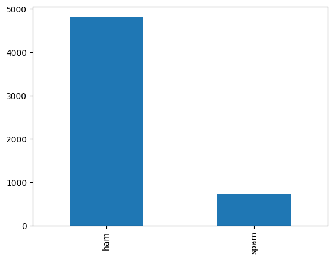

```python
y.value_counts().plot(kind='bar')
```

```python
print('최대 길이 : {}'.format(max(len(t) for t in x)))
print('평균 길이 : {}'.format((sum(map(len, x)) / len(x))))
```

```
최대 길이 : 477
평균 길이 : 45.35947595118449
```

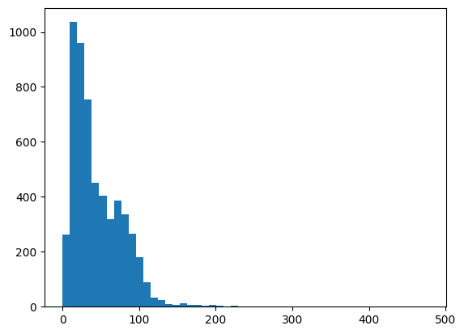

```python
import matplotlib.pyplot as plt

plt.hist([len(s) for s in x], bins=50)
plt.show()
```

```python
x_train, x_test, y_train, y_test = train_test_split(x, y, test_size = 0.2)

tfidf = TfidfVectorizer(min_df = 2, ngram_range = (1, 2), stop_words='english', strip_accents='unicode', norm='l2')

x_train = tfidf.fit_transform(x_train)
x_test = tfidf.transform(x_test)

le = LabelEncoder()
y_train = le.fit_transform(y_train)
y_test = le.transform(y_test)

print(x_train.shape, y_train.shape, x_test.shape, y_test.shape)
```

```
(4457, 6004) (4457,) (1115, 6004) (1115,)
```

```python
print(x_train[0])
```

```
  (0, 3402)	0.6251511222637454
  (0, 112)	0.5866938437103313
  (0, 3633)	0.5147585920456085
```

## 로지스틱 회귀 (Logistic Regression)

- 로지스틱 회귀는 이름에 회귀라는 단어가 들어가지만, 가능한 클래스가 2개인 이진 분류를 위한 모델
- 로지스틱 회귀의 예측 함수 정의

\begin{equation} \sigma(x) = \frac{1}{1 + e^{-x}} \\ \hat{y} = \sigma(w_0 + w_1 x_1 + ... + w_p x_p) \end{equation}

- $\sigma$: 시그모이드 함수
- 로지스틱 회귀 모델은 선형 회귀 모델에 시그모이드 함수를 적용
- 로지스틱 회귀의 학습 목표는 다음과 같은 목적 함수를 최소화 하는 파라미터 $w$를 찾는 것

\begin{equation} BinaryCrossEntropy = -\frac{1}{N}\sum_{i=1}^{N}y_i\log(\hat{y}_i) + (1-y_i)\log(1-\hat{y}_i) \end{equation}

- Logistic Regression은 특성상 다중 분류에는 적합하지 않음

```python
from sklearn.linear_model import LogisticRegression
from sklearn.metrics import accuracy_score
from sklearn.metrics import confusion_matrix
from sklearn.metrics import classification_report

LR = LogisticRegression()
LR.fit(x_train, y_train)

pred = LR.predict(x_test)

acc = accuracy_score(pred, y_test)
print(acc)

cm = confusion_matrix(y_test, pred)
print(cm)

cr = classification_report(y_test, pred)
print(cr)
```

```
0.9614349775784753
[[971   1]
 [ 42 101]]
              precision    recall  f1-score   support

           0       0.96      1.00      0.98       972
           1       0.99      0.71      0.82       143

    accuracy                           0.96      1115
   macro avg       0.97      0.85      0.90      1115
weighted avg       0.96      0.96      0.96      1115
```

## 나이브 베이스 분류기(Naive Bayes Classification)

- 베이즈 정리를 적용한 확률적 분류 알고리즘
- 모든 특성들이 독립임을 가정 (naive 가정)
- 입력 특성에 따라 3개의 분류기 존재
  - 가우시안 나이브 베이즈 분류기
  - 베르누이 나이브 베이즈 분류기
  - 다항 나이브 베이즈 분류기

```python
from sklearn.naive_bayes import MultinomialNB

NB = MultinomialNB()
NB.fit(x_train, y_train)

pred = NB.predict(x_test)

acc = accuracy_score(pred, y_test)
print(acc)

cm = confusion_matrix(y_test, pred)
print(cm)

cr = classification_report(y_test, pred)
print(cr)
```

```
0.9713004484304932
[[972   0]
 [ 32 111]]
              precision    recall  f1-score   support

           0       0.97      1.00      0.98       972
           1       1.00      0.78      0.87       143

    accuracy                           0.97      1115
   macro avg       0.98      0.89      0.93      1115
weighted avg       0.97      0.97      0.97      1115
```

## 서포트 벡터 머신(Support Vector Machines)

- 회귀, 분류, 이상치 탐지 등에 사용되는 지도학습 방법
- 클래스 사이의 경계에 위치한 데이터 포인트를 서포트 벡터(support vector)라고 함
- 각 서포트 벡터가 클래스 사이의 결정 경계를 구분하는데 얼마나 중요한지를 학습
- 각 서포트 벡터 사이의 마진이 가장 큰 방향으로 학습
- 서포트 벡터 까지의 거리와 서포트 벡터의 중요도를 기반으로 예측을 수행

```python
from sklearn.svm import SVC

SVC = SVC(kernel = 'linear')
SVC.fit(x_train, y_train)

pred = SVC.predict(x_test)

acc = accuracy_score(pred, y_test)
print(acc)

cm = confusion_matrix(y_test, pred)
print(cm)

cr = classification_report(y_test, pred)
print(cr)
```

```
0.9856502242152466
[[970   2]
 [ 14 129]]
              precision    recall  f1-score   support

           0       0.99      1.00      0.99       972
           1       0.98      0.90      0.94       143

    accuracy                           0.99      1115
   macro avg       0.99      0.95      0.97      1115
weighted avg       0.99      0.99      0.99      1115
```

## 확률적 경사 하강법 (Stochastic Gradient Descent)

```python
from sklearn.linear_model import SGDClassifier

SGD = SGDClassifier(alpha = 0.0001)
SGD.fit(x_train, y_train)

pred = SGD.predict(x_test)

acc = accuracy_score(pred, y_test)
print(acc)

cm = confusion_matrix(y_test, pred)
print(cm)

cr = classification_report(y_test, pred)
print(cr)
```

```
0.9865470852017937
[[969   3]
 [ 12 131]]
              precision    recall  f1-score   support

           0       0.99      1.00      0.99       972
           1       0.98      0.92      0.95       143

    accuracy                           0.99      1115
   macro avg       0.98      0.96      0.97      1115
weighted avg       0.99      0.99      0.99      1115
```

## 결정 트리(Decision Tree)

- 분류와 회귀에 사용되는 지도 학습 방법
- 데이터 특성으로 부터 추론된 결정 규칙을 통해 값을 예측
- **if-then-else** 결정 규칙을 통해 데이터 학습
- 트리의 깊이가 깊을 수록 복잡한 모델

```python
from sklearn.tree import DecisionTreeClassifier

DTC = DecisionTreeClassifier()
DTC.fit(x_train, y_train)

pred = DTC.predict(x_test)

acc = accuracy_score(pred, y_test)
print(acc)

cm = confusion_matrix(y_test, pred)
print(cm)

cr = classification_report(y_test, pred)
print(cr)
```

```
0.9659192825112107
[[952  20]
 [ 18 125]]
              precision    recall  f1-score   support

           0       0.98      0.98      0.98       972
           1       0.86      0.87      0.87       143

    accuracy                           0.97      1115
   macro avg       0.92      0.93      0.92      1115
weighted avg       0.97      0.97      0.97      1115
```

## 랜덤 포레스트 (Random Forest)

- 앙상블 학습 방법의 일종
- 다수의 결정 트리를 이용하여 분류 및 회귀 분석에 사용

```python
from sklearn.ensemble import RandomForestClassifier

RF = RandomForestClassifier()
RF.fit(x_train, y_train)

pred = RF.predict(x_test)

acc = accuracy_score(pred, y_test)
print(acc)

cm = confusion_matrix(y_test, pred)
print(cm)

cr = classification_report(y_test, pred)
print(cr)
```

```
0.9721973094170404
[[970   2]
 [ 29 114]]
              precision    recall  f1-score   support

           0       0.97      1.00      0.98       972
           1       0.98      0.80      0.88       143

    accuracy                           0.97      1115
   macro avg       0.98      0.90      0.93      1115
weighted avg       0.97      0.97      0.97      1115
```

## XGBoost

```python
from xgboost import XGBClassifier

XGB = XGBClassifier()
XGB.fit(x_train, y_train)

pred = XGB.predict(x_test)

acc = accuracy_score(pred, y_test)
print(acc)

cm = confusion_matrix(y_test, pred)
print(cm)

cr = classification_report(y_test, pred)
print(cr)
```

```
0.9713004484304932
[[967   5]
 [ 27 116]]
              precision    recall  f1-score   support

           0       0.97      0.99      0.98       972
           1       0.96      0.81      0.88       143

    accuracy                           0.97      1115
   macro avg       0.97      0.90      0.93      1115
weighted avg       0.97      0.97      0.97      1115
```

# 뉴스 그룹 데이터 분류

```python
from sklearn.datasets import fetch_20newsgroups
from sklearn.feature_extraction.text import TfidfTransformer

news = fetch_20newsgroups()

x = news.data
y = news.target
```

```python
print('최대길이 : {}'.format(max(len(i) for i in x)))
print('평균길이 : {}'.format((sum(map(len, x)) / len(x))))
```

```
최대길이 : 75154
평균길이 : 1949.3100583348064
```

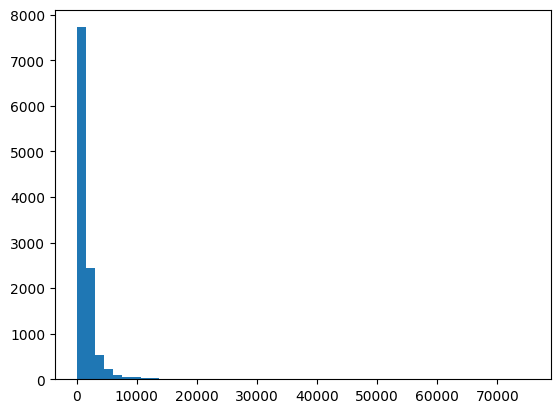

```python
import matplotlib.pyplot as plt

plt.hist([len(s) for s in x], bins = 50)
plt.show()
```

```python
x_train, x_test, y_train, y_test = train_test_split(x, y, test_size = 0.3)

tfidf = TfidfVectorizer(min_df=2, ngram_range=(1, 2), stop_words='english', strip_accents='unicode', norm='l2')

x_train = tfidf.fit_transform(x_train)
x_test = tfidf.transform(x_test)

le = LabelEncoder()

y_train = le.fit_transform(y_train)
y_test = le.transform(y_test)

print(x_train.shape, y_train.shape)
print(x_test.shape, y_test.shape)
```

```
(7919, 214964) (7919,)
(3395, 214964) (3395,)
```

## 나이브 베이스 분류기(Naive Bayes Classification)

```python
from sklearn.naive_bayes import MultinomialNB

NB = MultinomialNB()
NB.fit(x_train, y_train)

pred = NB.predict(x_test)

acc = accuracy_score(pred, y_test)
print(acc)

cm = confusion_matrix(y_test, pred)
print(cm)

cr = classification_report(y_test, pred)
print(cr)
```

```
0.8712812960235641
[[130   0   0   0   0   0   0   0   0   0   0   0   0   0   0   9   0   0
    0   1]
 [  0 150   0   5   0   7   6   0   0   0   2   1   0   1   1   1   0   0
    0   0]
 [  1   9 160   9   1   4   1   0   1   0   2   1   0   0   0   2   0   0
    0   0]
 [  0   5  10 152   7   1   3   2   0   0   0   2   2   1   2   0   1   0
    0   0]
 [  1   2   1   4 138   0   4   0   0   0   1   1   1   1   0   0   0   1
    0   0]
 [  0   8   1   1   0 143   0   1   1   0   1   8   1   0   0   0   1   0
    0   0]
 [  1   0   2   7   5   1 145   6   1   1   4   4   1   1   1   2   0   0
    0   0]
 [  2   1   1   0   0   1   4 157   2   1   2   0   3   0   0   1   1   0
    0   0]
 [  0   1   0   2   0   1   3   2 174   0   2   0   0   0   0   0   0   0
    0   0]
 [  0   1   0   0   1   1   2   1   0 173  12   0   1   1   0   1   0   0
    0   0]
 [  0   0   0   0   1   0   0   1   0   2 164   0   0   0   0   0   1   0
    0   0]
 [  0   1   1   0   0   0   0   0   0   0   1 166   0   0   0   0   0   0
    0   0]
 [  0   3   0   8   7   2   4   2   1   4   5   1 138   0   4   3   1   1
    0   0]
 [  0   3   1   0   3   1   1   2   2   0   0   2   0 150   4   5   1   0
    0   0]
 [  0   5   0   0   0   1   1   0   0   1   3   2   0   0 176   0   0   0
    0   0]
 [  1   0   0   1   1   1   1   1   0   0   0   1   1   1   0 162   0   0
    0   0]
 [  1   0   0   0   0   0   1   0   0   0   1   1   0   0   0   3 154   0
    0   0]
 [  0   0   0   0   0   0   0   1   0   0   0   1   1   0   0   0   0 173
    0   0]
 [  2   0   0   0   0   0   2   3   0   0   3   0   0   0   2   4   6   3
  114   0]
 [ 16   0   0   0   0   0   0   1   0   0   0   1   0   2   3  43   3   2
```

[output cut: 12 more lines]

```
           9       0.95      0.89      0.92       194
          10       0.81      0.97      0.88       169
          11       0.86      0.98      0.92       169
          12       0.93      0.75      0.83       184
          13       0.95      0.86      0.90       175
          14       0.91      0.93      0.92       189
          15       0.69      0.95      0.80       171
          16       0.91      0.96      0.93       161
          17       0.96      0.98      0.97       176
          18       0.99      0.82      0.90       139
          19       0.97      0.35      0.52       111

    accuracy                           0.87      3395
   macro avg       0.88      0.86      0.86      3395
weighted avg       0.88      0.87      0.87      3395
```

## 서포트 벡터 머신(Support Vector Machines)

```python
from sklearn.svm import SVC

SVC = SVC(kernel = 'linear')
SVC.fit(x_train, y_train)

pred = SVC.predict(x_test)

acc = accuracy_score(pred, y_test)
print(acc)

cm = confusion_matrix(y_test, pred)
print(cm)

cr = classification_report(y_test, pred)
print(cr)
```

```
0.9066273932253314
[[137   0   0   0   0   0   0   0   0   1   0   0   0   0   0   1   0   0
    0   1]
 [  0 158   0   4   1   3   6   0   0   0   0   0   2   0   0   0   0   0
    0   0]
 [  0  11 166   4   1   1   2   0   0   0   1   0   5   0   0   0   0   0
    0   0]
 [  0   4  10 161   5   1   4   1   0   0   0   0   2   0   0   0   0   0
    0   0]
 [  0   4   0   6 138   0   5   0   0   0   0   0   2   0   0   0   0   0
    0   0]
 [  0  12   4   3   0 143   1   0   0   0   0   0   3   0   0   0   0   0
    0   0]
 [  0   0   1   3   1   0 155   8   1   0   5   0   6   0   1   0   0   0
    1   0]
 [  0   1   0   0   0   1   9 158   1   1   1   0   4   0   0   0   0   0
    0   0]
 [  0   2   0   1   1   0   2   2 175   0   0   0   1   0   0   0   1   0
    0   0]
 [  0   1   0   0   2   0   3   0   1 183   2   0   1   1   0   0   0   0
    0   0]
 [  0   1   0   0   2   0   1   1   0   2 160   0   1   1   0   0   0   0
    0   0]
 [  0   4   0   1   0   0   0   0   0   0   0 164   0   0   0   0   0   0
    0   0]
 [  0   8   3   9   3   3   4   2   0   0   1   0 150   0   0   1   0   0
    0   0]
 [  0   6   2   1   1   1   2   2   0   0   0   0   4 155   1   0   0   0
    0   0]
 [  0   4   1   0   0   2   1   0   0   1   1   1   2   0 176   0   0   0
    0   0]
 [  2   2   0   1   1   0   2   1   1   2   0   0   0   0   0 158   0   0
    0   1]
 [  0   0   0   1   0   1   1   1   0   0   0   0   1   1   0   1 152   0
    1   1]
 [  0   0   0   0   0   0   1   1   0   0   0   0   0   0   0   0   0 174
    0   0]
 [  2   0   0   0   0   0   1   2   0   0   0   0   0   0   2   1   2   0
  129   0]
 [  6   2   0   0   0   0   0   1   0   0   0   0   0   2   3  10   0   0
```

[output cut: 12 more lines]

```
           9       0.96      0.94      0.95       194
          10       0.94      0.95      0.94       169
          11       0.99      0.97      0.98       169
          12       0.82      0.82      0.82       184
          13       0.97      0.89      0.93       175
          14       0.96      0.93      0.95       189
          15       0.92      0.92      0.92       171
          16       0.98      0.94      0.96       161
          17       1.00      0.99      0.99       176
          18       0.98      0.93      0.95       139
          19       0.97      0.77      0.86       111

    accuracy                           0.91      3395
   macro avg       0.91      0.91      0.91      3395
weighted avg       0.91      0.91      0.91      3395
```

## 확률적 경사 하강법 (Stocastic Gradient Decent)

```python
from sklearn.linear_model import SGDClassifier

SGD = SGDClassifier(alpha = 0.0001)
SGD.fit(x_train, y_train)

pred = SGD.predict(x_test)

acc = accuracy_score(pred, y_test)
print(acc)

cm = confusion_matrix(y_test, pred)
print(cm)

cr = classification_report(y_test, pred)
print(cr)
```

```
0.917820324005891
[[138   0   0   0   0   0   0   0   0   0   0   0   0   0   0   1   0   0
    0   1]
 [  0 146   3   4   3   7   4   0   0   0   2   0   2   2   0   0   0   1
    0   0]
 [  1   6 171   3   1   2   3   0   0   0   1   0   2   0   0   1   0   0
    0   0]
 [  0   3  14 154   3   2   6   1   0   0   0   1   2   0   1   0   1   0
    0   0]
 [  1   2   1   4 137   0   4   1   1   1   0   0   1   2   0   0   0   0
    0   0]
 [  0   5   5   2   0 146   1   0   0   2   0   3   2   0   0   0   0   0
    0   0]
 [  1   0   1   2   1   0 156   6   2   1   4   0   4   0   3   0   0   0
    0   1]
 [  1   2   0   0   0   0   6 160   3   2   1   0   1   0   0   0   0   0
    0   0]
 [  0   1   0   2   0   0   2   2 177   0   0   1   0   0   0   0   0   0
    0   0]
 [  0   1   0   0   0   0   2   0   0 188   2   0   1   0   0   0   0   0
    0   0]
 [  0   0   0   0   1   0   1   0   0   2 165   0   0   0   0   0   0   0
    0   0]
 [  0   2   0   0   0   0   0   0   0   0   0 167   0   0   0   0   0   0
    0   0]
 [  0   4   3   6   1   1   4   2   0   0   1   0 158   0   0   1   0   2
    1   0]
 [  0   4   2   0   1   1   3   0   0   0   0   2   3 158   0   1   0   0
    0   0]
 [  0   4   0   0   0   1   0   0   0   1   2   1   0   0 180   0   0   0
    0   0]
 [  2   1   0   0   0   0   0   1   1   1   0   0   1   2   0 161   0   0
    0   1]
 [  0   0   0   0   0   0   1   0   0   1   0   0   1   1   0   0 156   0
    0   1]
 [  0   0   0   0   0   0   0   1   0   0   0   0   0   0   0   0   0 175
    0   0]
 [  1   0   0   0   0   0   1   0   0   0   0   0   0   0   2   1   2   0
  132   0]
 [  6   0   0   0   0   0   0   1   0   0   0   0   0   1   2   8   1   0
```

[output cut: 12 more lines]

```
           9       0.94      0.97      0.96       194
          10       0.93      0.98      0.95       169
          11       0.95      0.99      0.97       169
          12       0.89      0.86      0.87       184
          13       0.95      0.90      0.93       175
          14       0.96      0.95      0.95       189
          15       0.93      0.94      0.93       171
          16       0.97      0.97      0.97       161
          17       0.98      0.99      0.99       176
          18       0.99      0.95      0.97       139
          19       0.96      0.82      0.88       111

    accuracy                           0.92      3395
   macro avg       0.92      0.92      0.92      3395
weighted avg       0.92      0.92      0.92      3395
```

## 결정 트리(Decision Tree)

```python
from sklearn.tree import DecisionTreeClassifier

DTC = DecisionTreeClassifier()
DTC.fit(x_train, y_train)

pred = DTC.predict(x_test)

acc = accuracy_score(pred, y_test)
print(acc)

cm = confusion_matrix(y_test, pred)
print(cm)

cr = classification_report(y_test, pred)
print(cr)
```

```
0.6353460972017673
[[ 95   2   0   1   3   1   0   3   0   0   1   2   3   1   1   4   3   2
    4  14]
 [  1  84  14   7  11   8   9   2   5   7   2   1   8   6   4   0   0   2
    2   1]
 [  1  17 119  17   3   8   3   1   1   0   1   0   8   1   2   1   2   0
    3   3]
 [  1  14  24  76  11   7  11   6   2   5   3   0  14   5   1   0   0   3
    4   1]
 [  0   9   3  10  85   3   9   1   3   4   0   4  12   2   3   2   1   1
    3   0]
 [  3  11   9   4   5 102   2   6   4   5   1   2   3   3   3   2   0   0
    0   1]
 [  1   1   3   8   7   3 110   6   3   4   3   1  16   4   2   0   5   2
    3   0]
 [  0   0   5   4   5   2   7 116  12   2   1   1   7   1   2   4   2   1
    2   2]
 [  1   1   3   0   0   2   2   8 152   2   5   0   1   2   1   1   0   1
    2   1]
 [  4   7   2   3   4   6   3   2   4 122  16   0   6   5   2   1   1   2
    3   1]
 [  1   2   0   0   5   2   2   1   0  22 124   2   2   0   1   1   0   1
    2   1]
 [  0   2   1   2   2   2   0   1   2   1   4 140   1   2   3   0   3   1
    2   0]
 [  0   9   4  17   6   9   7  12   9   2   3   5  84   4   1   1   4   0
    3   4]
 [  3   6   4   4   4   6   3   0   4   3   3   1  11 110   1   2   0   1
    5   4]
 [  0   2   1   1   5   5   3   4   8   3   5   1   6   0 138   0   4   0
    2   1]
 [ 13   1   0   3   3   2   0   2   1   3   1   0   3   2   0 122   1   0
    1  13]
 [  1   0   2   1   2   1   2   3   2   3   3   3   3   3   2   4 116   1
    7   2]
 [  4   2   0   1   1   2   0   3   3   1   1   0   2   1   3   1   0 138
    8   5]
 [  6   0   3   0   2   0   2   4   3   2   2   3   2   6   5   3   8   3
   79   6]
 [ 17   3   0   0   3   1   1   1   0   5   2   2   3   1   1  15   4   1
```

[output cut: 12 more lines]

```
           9       0.62      0.63      0.63       194
          10       0.69      0.73      0.71       169
          11       0.83      0.83      0.83       169
          12       0.43      0.46      0.44       184
          13       0.69      0.63      0.66       175
          14       0.78      0.73      0.76       189
          15       0.74      0.71      0.73       171
          16       0.75      0.72      0.74       161
          17       0.86      0.78      0.82       176
          18       0.56      0.57      0.56       139
          19       0.43      0.41      0.42       111

    accuracy                           0.64      3395
   macro avg       0.63      0.63      0.63      3395
weighted avg       0.64      0.64      0.64      3395
```

## 랜덤 포레스트 (Random Forest)

```python
from sklearn.ensemble import RandomForestClassifier

RF = RandomForestClassifier()
RF.fit(x_train, y_train)

pred = RF.predict(x_test)

acc = accuracy_score(pred, y_test)
print(acc)

cm = confusion_matrix(y_test, pred)
print(cm)

cr = classification_report(y_test, pred)
print(cr)
```

```
0.8530191458026509
[[125   0   0   0   0   0   0   0   0   1   0   0   0   1   1  10   0   1
    1   0]
 [  0 144   8   3   4   4   7   0   0   1   0   0   1   1   0   0   0   1
    0   0]
 [  0   7 168   4   0   3   3   2   0   0   1   1   1   0   1   0   0   0
    0   0]
 [  0  14  22 129   5   1  10   2   1   0   1   0   2   0   1   0   0   0
    0   0]
 [  0   3   3   9 129   0   6   0   1   1   0   0   1   1   1   0   0   0
    0   0]
 [  0  14   7   1   0 138   0   0   0   0   2   3   0   1   0   0   0   0
    0   0]
 [  0   0   1   4   3   0 161   5   1   1   1   1   2   1   1   0   0   0
    0   0]
 [  0   5   1   2   2   0   8 151   2   0   2   0   1   0   0   2   0   0
    0   0]
 [  0   1   0   1   0   1   5   6 171   0   0   0   0   0   0   0   0   0
    0   0]
 [  0   2   1   0   1   2   4   0   0 172   9   0   1   2   0   0   0   0
    0   0]
 [  0   0   1   0   1   0   0   1   0   3 161   0   1   1   0   0   0   0
    0   0]
 [  0   2   1   0   2   2   1   0   0   1   0 158   0   0   0   0   2   0
    0   0]
 [  0  10   1  15  10   1  13   4   1   1   2   2 118   1   4   0   1   0
    0   0]
 [  0   5   1   2   4   4   2   0   0   4   0   0   6 144   3   0   0   0
    0   0]
 [  0   5   1   1   3   5   2   0   0   0   0   0   0   0 172   0   0   0
    0   0]
 [  2   4   0   0   0   0   0   1   0   0   1   0   1   0   0 162   0   0
    0   0]
 [  0   0   0   0   2   1   2   0   1   0   1   0   1   1   0   4 146   0
    2   0]
 [  0   0   0   0   0   0   1   1   0   0   0   0   1   0   1   0   1 171
    0   0]
 [  1   2   0   0   0   0   4   1   2   2   1   2   0   0   3   5   4   2
  110   0]
 [  4   2   0   2   1   1   0   0   0   0   1   0   0   1   2  27   1   1
```

[output cut: 12 more lines]

```
           9       0.92      0.89      0.90       194
          10       0.88      0.95      0.91       169
          11       0.95      0.93      0.94       169
          12       0.86      0.64      0.74       184
          13       0.93      0.82      0.87       175
          14       0.91      0.91      0.91       189
          15       0.77      0.95      0.85       171
          16       0.94      0.91      0.92       161
          17       0.97      0.97      0.97       176
          18       0.96      0.79      0.87       139
          19       1.00      0.59      0.75       111

    accuracy                           0.85      3395
   macro avg       0.87      0.85      0.85      3395
weighted avg       0.86      0.85      0.85      3395
```

## XGBoost

```python
from xgboost import XGBClassifier

XGB = XGBClassifier()
XGB.fit(x_train, y_train)

pred = XGB.predict(x_test)

acc = accuracy_score(pred, y_test)
print(acc)

cm = confusion_matrix(y_test, pred)
print(cm)

cr = classification_report(y_test, pred)
print(cr)
```

```
0.8170839469808542
[[117   1   0   1   0   0   0   0   0   0   0   0   2   2   3   4   2   4
    0   4]
 [  0 128  12   6   5   6   7   1   0   2   0   0   4   2   0   0   0   1
    0   0]
 [  0   8 155   9   1   4   0   0   1   2   2   1   4   0   2   2   0   0
    0   0]
 [  0   9  19 125   8   2   9   1   1   0   2   0   9   0   0   1   2   0
    0   0]
 [  0   1   1  11 127   0   7   0   1   0   0   0   6   0   0   1   0   0
    0   0]
 [  0   9   9   7   2 128   0   0   0   0   0   3   4   2   1   1   0   0
    0   0]
 [  0   5   2   6   5   2 133   7   4   3   1   0  10   2   0   0   1   0
    1   0]
 [  0   2   1   2   2   3   9 143   5   0   0   0   4   1   0   3   0   0
    1   0]
 [  0   2   0   1   0   0   3   6 167   0   0   0   1   3   0   1   0   0
    1   0]
 [  0   2   1   3   3   1   0   3   0 161   8   0   6   2   0   3   0   1
    0   0]
 [  0   0   0   1   1   0   0   2   0   6 154   0   2   1   1   1   0   0
    0   0]
 [  0   2   0   1   1   1   0   0   0   0   0 153   2   3   1   1   2   0
    2   0]
 [  0   3   1  13   8   2   3   4   2   2   1   2 134   4   1   0   3   0
    1   0]
 [  0   6   1   5   2   1   1   2   1   1   0   0   9 144   1   1   0   0
    0   0]
 [  0   6   0   4   4   2   1   1   0   0   0   0   2   1 167   0   0   0
    1   0]
 [  2   2   0   1   0   1   0   1   0   3   0   0   3   0   0 151   0   1
    0   6]
 [  0   0   0   2   1   1   1   1   0   1   0   2   2   3   0   0 141   0
    4   2]
 [  0   1   0   0   0   0   0   2   0   0   0   0   4   2   0   1   1 162
    3   0]
 [  1   0   0   2   0   0   1   2   3   0   0   1   3   1   2   4   7   3
  109   0]
 [  8   0   0   1   0   0   0   0   0   0   1   1   4   3   0  13   2   1
```

[output cut: 12 more lines]

```
           9       0.89      0.83      0.86       194
          10       0.91      0.91      0.91       169
          11       0.94      0.91      0.92       169
          12       0.62      0.73      0.67       184
          13       0.82      0.82      0.82       175
          14       0.93      0.88      0.91       189
          15       0.80      0.88      0.84       171
          16       0.88      0.88      0.88       161
          17       0.94      0.92      0.93       176
          18       0.87      0.78      0.83       139
          19       0.86      0.68      0.76       111

    accuracy                           0.82      3395
   macro avg       0.83      0.82      0.82      3395
weighted avg       0.82      0.82      0.82      3395
```

# 한국어 형태소 분석기 설치

- 한국어 자연어 처리 konlpy 라이브러리
- 형태소 분석기 MeCab 설치
- 설치 명령어:

`!curl -s https://raw.githubusercontent.com/teddylee777/machine-learning/master/99-Misc/01-Colab/mecab-colab.sh | bash`

```python
!curl -s https://raw.githubusercontent.com/teddylee777/machine-learning/master/99-Misc/01-Colab/mecab-colab.sh | bash
```

# 영화 리뷰 데이터 분류

- 영화 리뷰 데이터 다운로드

(https://github.com/e9t/nsmc/raw/master/ratings.txt)

```python
!wget https://github.com/e9t/nsmc/raw/master/ratings.txt
```

```
--2023-04-26 11:35:00--  https://github.com/e9t/nsmc/raw/master/ratings.txt
Resolving github.com (github.com)... 140.82.121.3
Connecting to github.com (github.com)|140.82.121.3|:443... connected.
HTTP request sent, awaiting response... 302 Found
Location: https://raw.githubusercontent.com/e9t/nsmc/master/ratings.txt [following]
--2023-04-26 11:35:00--  https://raw.githubusercontent.com/e9t/nsmc/master/ratings.txt
Resolving raw.githubusercontent.com (raw.githubusercontent.com)... 185.199.111.133, 185.199.110.133, 185.199.109.133, ...
Connecting to raw.githubusercontent.com (raw.githubusercontent.com)|185.199.111.133|:443... connected.
HTTP request sent, awaiting response... 200 OK
Length: 19515078 (19M) [text/plain]
Saving to: ‘ratings.txt’

ratings.txt         100%[===================>]  18.61M  --.-KB/s    in 0.07s

2023-04-26 11:35:01 (277 MB/s) - ‘ratings.txt’ saved [19515078/19515078]
```

```python
df = pd.read_table('ratings.txt')
print(df.shape)
df.head()
```

```
(200000, 3)
```

|  | id | document | label |
| --- | --- | --- | --- |
| 0 | 8112052 | 어릴때보고 지금다시봐도 재밌어요ㅋㅋ | 1 |
| 1 | 8132799 | 디자인을 배우는 학생으로, 외국디자이너와 그들이 일군 전통을 통해 발전해가는 문화산... | 1 |
| 2 | 4655635 | 폴리스스토리 시리즈는 1부터 뉴까지 버릴께 하나도 없음.. 최고. | 1 |
| 3 | 9251303 | 와.. 연기가 진짜 개쩔구나.. 지루할거라고 생각했는데 몰입해서 봤다.. 그래 이런... | 1 |
| 4 | 10067386 | 안개 자욱한 밤하늘에 떠 있는 초승달 같은 영화. | 1 |

```python
import numpy as np

df.drop_duplicates(subset = ['document'], inplace=True)
df['document'].replace('', np.nan, inplace=True)
df = df.dropna(how='any')

print(df.shape)
df.head()
```

```
(194543, 3)
```

|  | id | document | label |
| --- | --- | --- | --- |
| 0 | 8112052 | 어릴때보고 지금다시봐도 재밌어요ㅋㅋ | 1 |
| 1 | 8132799 | 디자인을 배우는 학생으로, 외국디자이너와 그들이 일군 전통을 통해 발전해가는 문화산... | 1 |
| 2 | 4655635 | 폴리스스토리 시리즈는 1부터 뉴까지 버릴께 하나도 없음.. 최고. | 1 |
| 3 | 9251303 | 와.. 연기가 진짜 개쩔구나.. 지루할거라고 생각했는데 몰입해서 봤다.. 그래 이런... | 1 |
| 4 | 10067386 | 안개 자욱한 밤하늘에 떠 있는 초승달 같은 영화. | 1 |

```python
x = df.document
y = df.label

x_train, x_test, y_train, y_test = train_test_split(x, y, test_size = 0.2)

tfidf = TfidfVectorizer(min_df=2, ngram_range=(1, 2), strip_accents='unicode', norm='l2')

x_train = tfidf.fit_transform(x_train)
x_test = tfidf.transform(x_test)

le = LabelEncoder()

y_train = le.fit_transform(y_train)
y_test = le.transform(y_test)

print(x_train.shape, y_train.shape)
print(x_test.shape, y_test.shape)
```

```
(155634, 137011) (155634,)
(38909, 137011) (38909,)
```

## 로지스틱 회귀 (Logistic Regression)

```python
LR = LogisticRegression()
LR.fit(x_train, y_train)

pred = LR.predict(x_test)

acc = accuracy_score(pred, y_test)
print(acc)

cm = confusion_matrix(y_test, pred)
print(cm)

cr = classification_report(y_test, pred)
print(cr)
```

```
0.8213266853427228
[[16540  2955]
 [ 3997 15417]]
              precision    recall  f1-score   support

           0       0.81      0.85      0.83     19495
           1       0.84      0.79      0.82     19414

    accuracy                           0.82     38909
   macro avg       0.82      0.82      0.82     38909
weighted avg       0.82      0.82      0.82     38909
```

## 나이브 베이스 분류기(Naive Bayes Classification)

```python
NB = MultinomialNB()
NB.fit(x_train, y_train)

pred = NB.predict(x_test)

acc = accuracy_score(pred, y_test)
print(acc)

cm = confusion_matrix(y_test, pred)
print(cm)

cr = classification_report(y_test, pred)
print(cr)
```

```
0.8373384049962733
[[15619  3876]
 [ 2453 16961]]
              precision    recall  f1-score   support

           0       0.86      0.80      0.83     19495
           1       0.81      0.87      0.84     19414

    accuracy                           0.84     38909
   macro avg       0.84      0.84      0.84     38909
weighted avg       0.84      0.84      0.84     38909
```

## 서포트 벡터 머신(Support Vector Machines)

```python
from sklearn.svm import SVC

SVC = SVC(kernel = 'linear')
SVC.fit(x_train, y_train)

pred = SVC.predict(x_test)

acc = accuracy_score(pred, y_test)
print(acc)

cm = confusion_matrix(y_test, pred)
print(cm)

cr = classification_report(y_test, pred)
print(cr)
```

```
0.8247192166336837
[[16597  2898]
 [ 3922 15492]]
              precision    recall  f1-score   support

           0       0.81      0.85      0.83     19495
           1       0.84      0.80      0.82     19414

    accuracy                           0.82     38909
   macro avg       0.83      0.82      0.82     38909
weighted avg       0.83      0.82      0.82     38909
```

## 확률적 경사 하강법 (Stocastic Gradient Decent)

```python
from sklearn.linear_model import SGDClassifier

SGD = SGDClassifier(alpha = 0.0001)
SGD.fit(x_train, y_train)

pred = SGD.predict(x_test)

acc = accuracy_score(pred, y_test)
print(acc)

cm = confusion_matrix(y_test, pred)
print(cm)

cr = classification_report(y_test, pred)
print(cr)
```

```
0.7968079364671413
[[16706  2789]
 [ 5117 14297]]
              precision    recall  f1-score   support

           0       0.77      0.86      0.81     19495
           1       0.84      0.74      0.78     19414

    accuracy                           0.80     38909
   macro avg       0.80      0.80      0.80     38909
weighted avg       0.80      0.80      0.80     38909
```

## 결정 트리(Decision Tree)

```python
from sklearn.tree import DecisionTreeClassifier

DTC = DecisionTreeClassifier()
DTC.fit(x_train, y_train)

pred = DTC.predict(x_test)

acc = accuracy_score(pred, y_test)
print(acc)

cm = confusion_matrix(y_test, pred)
print(cm)

cr = classification_report(y_test, pred)
print(cr)
```

```
0.7284175897607238
[[13331  6164]
 [ 4403 15011]]
              precision    recall  f1-score   support

           0       0.75      0.68      0.72     19495
           1       0.71      0.77      0.74     19414

    accuracy                           0.73     38909
   macro avg       0.73      0.73      0.73     38909
weighted avg       0.73      0.73      0.73     38909
```

## 랜덤 포레스트 (Random Forest)

```python
from sklearn.ensemble import RandomForestClassifier

RF = RandomForestClassifier()
RF.fit(x_train, y_train)

pred = RF.predict(x_test)

acc = accuracy_score(pred, y_test)
print(acc)

cm = confusion_matrix(y_test, pred)
print(cm)

cr = classification_report(y_test, pred)
print(cr)
```

```
0.7811817317330181
[[14427  5068]
 [ 3446 15968]]
              precision    recall  f1-score   support

           0       0.81      0.74      0.77     19495
           1       0.76      0.82      0.79     19414

    accuracy                           0.78     38909
   macro avg       0.78      0.78      0.78     38909
weighted avg       0.78      0.78      0.78     38909
```

## XGBoost

```python
from xgboost import XGBClassifier

XGB = XGBClassifier()
XGB.fit(x_train, y_train)

pred = XGB.predict(x_test)

acc = accuracy_score(pred, y_test)
print(acc)

cm = confusion_matrix(y_test, pred)
print(cm)

cr = classification_report(y_test, pred)
print(cr)
```

```
0.7072656711814748
[[16652  2843]
 [ 8547 10867]]
              precision    recall  f1-score   support

           0       0.66      0.85      0.75     19495
           1       0.79      0.56      0.66     19414

    accuracy                           0.71     38909
   macro avg       0.73      0.71      0.70     38909
weighted avg       0.73      0.71      0.70     38909
```

# 쇼핑 리뷰 데이터 분류

- 쇼핑 리뷰 데이터 다운로드

(https://raw.githubusercontent.com/bab2min/corpus/master/sentiment/naver_shopping.txt)

```python
!wget https://raw.githubusercontent.com/bab2min/corpus/master/sentiment/naver_shopping.txt
```

```
--2023-04-26 13:17:38--  https://raw.githubusercontent.com/bab2min/corpus/master/sentiment/naver_shopping.txt
Resolving raw.githubusercontent.com (raw.githubusercontent.com)... 185.199.108.133, 185.199.110.133, 185.199.109.133, ...
Connecting to raw.githubusercontent.com (raw.githubusercontent.com)|185.199.108.133|:443... connected.
HTTP request sent, awaiting response... 200 OK
Length: 20623547 (20M) [text/plain]
Saving to: ‘naver_shopping.txt’

naver_shopping.txt  100%[===================>]  19.67M  --.-KB/s    in 0.06s

2023-04-26 13:17:39 (339 MB/s) - ‘naver_shopping.txt’ saved [20623547/20623547]
```

```python
df = pd.read_table('naver_shopping.txt', names=['ratings', 'reviews'])
print(df.shape)
df.head()
```

```
(200000, 2)
```

|  | ratings | reviews |
| --- | --- | --- |
| 0 | 5 | 배공빠르고 굿 |
| 1 | 2 | 택배가 엉망이네용 저희집 밑에층에 말도없이 놔두고가고 |
| 2 | 5 | 아주좋아요 바지 정말 좋아서2개 더 구매했어요 이가격에 대박입니다. 바느질이 조금 ... |
| 3 | 2 | 선물용으로 빨리 받아서 전달했어야 하는 상품이었는데 머그컵만 와서 당황했습니다. 전... |
| 4 | 5 | 민트색상 예뻐요. 옆 손잡이는 거는 용도로도 사용되네요 ㅎㅎ |

```python
import numpy as np

df.drop_duplicates(subset = ['reviews'], inplace=True)
df['reviews'].replace('', np.nan, inplace=True)
df = df.dropna(how='any')

print(df.shape)
df.head()
```

```
(199908, 2)
```

|  | ratings | reviews |
| --- | --- | --- |
| 0 | 5 | 배공빠르고 굿 |
| 1 | 2 | 택배가 엉망이네용 저희집 밑에층에 말도없이 놔두고가고 |
| 2 | 5 | 아주좋아요 바지 정말 좋아서2개 더 구매했어요 이가격에 대박입니다. 바느질이 조금 ... |
| 3 | 2 | 선물용으로 빨리 받아서 전달했어야 하는 상품이었는데 머그컵만 와서 당황했습니다. 전... |
| 4 | 5 | 민트색상 예뻐요. 옆 손잡이는 거는 용도로도 사용되네요 ㅎㅎ |

```python
x = df.reviews
y = df.ratings

x_train, x_test, y_train, y_test = train_test_split(x, y, test_size = 0.2)

tfidf = TfidfVectorizer(min_df=2, ngram_range=(1, 2), strip_accents='unicode', norm='l2')

x_train = tfidf.fit_transform(x_train)
x_test = tfidf.transform(x_test)

le = LabelEncoder()

y_train = le.fit_transform(y_train)
y_test = le.transform(y_test)

print(x_train.shape, y_train.shape)
print(x_test.shape, y_test.shape)
```

```
(159926, 151086) (159926,)
(39982, 151086) (39982,)
```

## 나이브 베이스 분류기(Naive Bayes Classification)

```python
NB = MultinomialNB()
NB.fit(x_train, y_train)

pred = NB.predict(x_test)

acc = accuracy_score(pred, y_test)
print(acc)

cm = confusion_matrix(y_test, pred)
print(cm)

cr = classification_report(y_test, pred)
print(cr)
```

```
0.6571707268270722
[[  596  5552     0  1044]
 [  337 10331     0  2224]
 [    2   640     1  3072]
 [   15   820     1 15347]]
              precision    recall  f1-score   support

           0       0.63      0.08      0.15      7192
           1       0.60      0.80      0.68     12892
           2       0.50      0.00      0.00      3715
           3       0.71      0.95      0.81     16183

    accuracy                           0.66     39982
   macro avg       0.61      0.46      0.41     39982
weighted avg       0.64      0.66      0.57     39982
```

## 서포트 벡터 머신(Support Vector Machines)

```python
from sklearn.svm import SVC

SVC = SVC(kernel = 'linear')
SVC.fit(x_train, y_train)

pred = SVC.predict(x_test)

acc = accuracy_score(pred, y_test)
print(acc)

cm = confusion_matrix(y_test, pred)
print(cm)

cr = classification_report(y_test, pred)
print(cr)
```

```
0.6568455805112301
[[ 1934  4761    11   486]
 [ 1584 10105    52  1151]
 [   38   805   113  2759]
 [  150  1807   116 14110]]
              precision    recall  f1-score   support

           0       0.52      0.27      0.35      7192
           1       0.58      0.78      0.67     12892
           2       0.39      0.03      0.06      3715
           3       0.76      0.87      0.81     16183

    accuracy                           0.66     39982
   macro avg       0.56      0.49      0.47     39982
weighted avg       0.62      0.66      0.61     39982
```

## 확률적 경사 하강법 (Stocastic Gradient Decent)

```python
from sklearn.linear_model import SGDClassifier

SGD = SGDClassifier(alpha = 0.0001)
SGD.fit(x_train, y_train)

pred = SGD.predict(x_test)

acc = accuracy_score(pred, y_test)
print(acc)

cm = confusion_matrix(y_test, pred)
print(cm)

cr = classification_report(y_test, pred)
print(cr)
```

```
0.6355109799409734
[[  625  4886     2  1679]
 [  386  9420    11  3075]
 [    4   569     6  3136]
 [   16   802     7 15358]]
              precision    recall  f1-score   support

           0       0.61      0.09      0.15      7192
           1       0.60      0.73      0.66     12892
           2       0.23      0.00      0.00      3715
           3       0.66      0.95      0.78     16183

    accuracy                           0.64     39982
   macro avg       0.52      0.44      0.40     39982
weighted avg       0.59      0.64      0.56     39982
```

## 결정 트리(Decision Tree)

```python
from sklearn.tree import DecisionTreeClassifier

DTC = DecisionTreeClassifier()
DTC.fit(x_train, y_train)

pred = DTC.predict(x_test)

acc = accuracy_score(pred, y_test)
print(acc)

cm = confusion_matrix(y_test, pred)
print(cm)

cr = classification_report(y_test, pred)
print(cr)
```

```
0.5520484217898054
[[ 1959  3540   145  1548]
 [ 2531  6963   336  3062]
 [  165   678   380  2492]
 [  572  1598  1243 12770]]
              precision    recall  f1-score   support

           0       0.37      0.27      0.32      7192
           1       0.54      0.54      0.54     12892
           2       0.18      0.10      0.13      3715
           3       0.64      0.79      0.71     16183

    accuracy                           0.55     39982
   macro avg       0.44      0.43      0.42     39982
weighted avg       0.52      0.55      0.53     39982
```

## 랜덤 포레스트 (Random Forest)

```python
from sklearn.ensemble import RandomForestClassifier

RF = RandomForestClassifier()
RF.fit(x_train, y_train)

pred = RF.predict(x_test)

acc = accuracy_score(pred, y_test)
print(acc)

cm = confusion_matrix(y_test, pred)
print(cm)

cr = classification_report(y_test, pred)
print(cr)
```

```
0.6238057125706568
[[ 1126  4698    16  1352]
 [  974  9239    41  2638]
 [   30   707    35  2943]
 [  136  1363   143 14541]]
              precision    recall  f1-score   support

           0       0.50      0.16      0.24      7192
           1       0.58      0.72      0.64     12892
           2       0.15      0.01      0.02      3715
           3       0.68      0.90      0.77     16183

    accuracy                           0.62     39982
   macro avg       0.48      0.45      0.42     39982
weighted avg       0.56      0.62      0.56     39982
```

## XGBoost

```python
from xgboost import XGBClassifier

XGB = XGBClassifier()
XGB.fit(x_train, y_train)

pred = XGB.predict(x_test)

acc = accuracy_score(pred, y_test)
print(acc)

cm = confusion_matrix(y_test, pred)
print(cm)

cr = classification_report(y_test, pred)
print(cr)
```

```
0.596493422039918
[[  761  5690     6   735]
 [  501 10892    44  1455]
 [    8  1247    79  2381]
 [   26  3965    75 12117]]
              precision    recall  f1-score   support

           0       0.59      0.11      0.18      7192
           1       0.50      0.84      0.63     12892
           2       0.39      0.02      0.04      3715
           3       0.73      0.75      0.74     16183

    accuracy                           0.60     39982
   macro avg       0.55      0.43      0.40     39982
weighted avg       0.60      0.60      0.54     39982
```